# XU, Shu-xian (徐淑娴)

#### Currently seeking a *Postdoctoral Researcher*, *Scientist*, or other *scientific position*.

### Contact Info

Citation (Update: June-25-2024)

shuxianxu@outlook.com

ORCID: 0000-0003-3769-2525

Google Scholar: [Shuxian Xu](https://scholar.google.com/citations?user=SozX69MAAAAJ)

Research Gate: [Shuxian Xu](https://www.researchgate.net/profile/Shuxian-Xu-3)

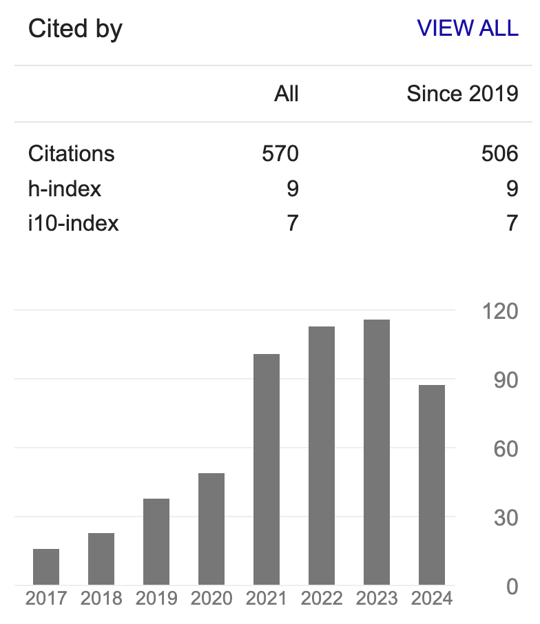

## RESEARCH AREAS

- Integrated clinical and pre-clinical research: neuroinflammation, insulin resistance, and depression via brain-derived extracellular vesicles (EVs).
- Roles of EVs in mediating brain communication and plasticity.
- Connection between cognition and neurogenesis in electroconvulsive therapy (ECT).

## SKILLS

- Design and conduct pre- and clinical studies.
- Single cell / cell culture samples.
- EV isolation, validation, and downstreams using plasma / cell culture / urine samples.
- Analyze data utilizing various statistical tools.

## EDUCATION

#### Wuhan University, Wuhan, China (2020 - 2024)

- Ph.D. candidate in Psychiatry.
- Main research contents:

  Investigating the status of neuroinflammation, insulin resistance and neurogenesis in patients with major depressive disorder (MDD) using plasma/serum astrocyte-derived extracellular vesicles (ADEVs) and neuro-derived EVs (NDEVs), and the changes before and after ECT.

#### McGill University, Montreal, Canada (2023 - 2024)

- Graduate Research Trainee.
- Main research contents:

  Extracellular vesicle mediation of brain communication and plasticity.

#### Anhui Medical University, Hefei, China (2014 - 2017)

- M.S. in Psychiatry.
- Main research contents:

  New strategy for electroconvulsive therapy (ECT) in mental health patients: maintain efficacy while minimizing side effects.

#### Southern Medical University, Guangzhou, China (2009 - 2014)

- M.D. equivalent

## PROFESSIONAL EXPERIENCE

#### Department of Psychiatry, Huizhou Mental Health Center (Second People’s Hospital of Huizhou)

- Resident Psychiatrist, Residency training program.

#### Service as Reviewer

- *Frontiers in Psychiatry.*
- *BMC Psychiatry.*
- *BMC Cardiovascular Disorders.*

## Publications

(Note: #First author, *Corresponding author, the selected publications were marked in **bold**)

1. Wang, C.#, Li, N.#, Feng, Y., Sun, S., Rong, J., Xie, X. H., **Xu, S. X.** & Liu, Z.* (2024). Effects of autotaxin and lysophosphatidic acid deficiencies on depression-like behaviors in mice exposed to chronic unpredictable mild stress. *Neurobiology of Stress*, *30*, 100632.[DOI](https://doi.org/10.1016/j.ynstr.2024.100632)
2. Zhang, H.#, Xie, X. H., **Xu, S. X.**, Wang, C., Sun, S., Song, X., Li, R., Li, N., Feng, Y., Duan, H., Li, D., & Liu, Z.* (2024). Oligodendrocyte-derived exosomes-containing SIRT2 ameliorates depressive-like behaviors and restores hippocampal neurogenesis and synaptic plasticity via the AKT/GSK-3β pathway in depressed mice. *CNS neuroscience & therapeutics*, *30*(3), e14661.[DOI](https://doi.org/10.1111/cns.14661) [PMID](https://pubmed.ncbi.nlm.nih.gov/38439616/)
3. Xie, X. H.#*, Chen, M. M.#, **Xu, S. X.**, Mei, J. Yang, Q., Wang, C. & Liu, Z.* (2024). Urinary Astrocyte-derived Extracellular Vesicles: A Non-invasive Tool for Capturing Human *In Vivo* Molecular “Movies” of Brain. *medRxiv,* 2024.01.12.24301104. [DOI](https://doi.org/10.1101/2024.01.12.24301104)
4. Rong, J.#, Sun, S., **Xu, S. X.**, Xie, X. H., Wang, C., Chen, G., Kang, L., Xiang, D., & Liu, Z.* (2024). The Neuroprotective Effects of BMSC-Derived Exosomes against Glutamate-Induced HT22 Cell Cytotoxicity. *Neuroscience*, S0306-4522(24)00039-3. [DOI](https://doi.org/10.1016/j.neuroscience.2024.01.023) [PMID](https://pubmed.ncbi.nlm.nih.gov/38342336/)
5. Xie, X. H.#, **Xu, S. X.#**, Yao, L., Chen, M. M., Zhang, H., Wang, C.,Nagy, C., & Liu, Z.* (2023). **Altered *In Vivo* Early Neurogenesis Traits in Patients with Depression: Evidence from Neuron-Derived Extracellular Vesicles and Electroconvulsive Therapy.** *Brain stimulation*, *17*(1), 19–28. [DOI](https://doi.org/10.1016/j.brs.2023.12.006) [PMID](https://pubmed.ncbi.nlm.nih.gov/38101468/)
6. Ma, S.#, Xie, X. H., Deng, Z., Wang, W., Xiang, D., Yao, L., Kang, L., **Xu, S. X.**, Wang, H., Wang, G., Yang, J.*, & Liu, Z.* (2023). A machine learning analysis of “big” metabolomics data for classifying depression: model development and validation. *Biological psychiatry*, S0006-3223(23)01792-4. Advance online publication. [DOI](https://doi.org/10.1016/j.biopsych.2023.12.015) [PMID](https://pubmed.ncbi.nlm.nih.gov/38142718/)
7. Huang, T. Y.#, Chen, L. C.#, Li, X. P.#, Li, W. H., **Xu, S. X.**, Nagy, C., Ibrahim, P., Nie, Z. W., Yang, N. Y., Zeng, L., Huang, H. W., Turecki, G., Xie, X. H.* (2023). Elevated Triglycerides and Low Triiodothyronine: Key Risk Factors for Coronary Artery Calcification in Schizophrenia Patients. *Schizophrenia research*, *264*, 113-121. [PMID](https://pubmed.ncbi.nlm.nih.gov/38128342/) [DOI](https://doi.org/10.1016/j.schres.2023.12.007)
8. Zhou, E.#, Wang, W., Ma, S., Xie, X. H., Kang, L., **Xu, S. X.**, Deng, Z., Gong, Q., Nie, Z., Yao, L., Bu, L.*, Wang, F.*, & Liu, Z.* (2023). Prediction of anxious depression using multimodal neuroimaging and machine learning. *NeuroImage*, *285*, 120499. [DOI](https://doi.org/10.1016/j.neuroimage.2023.120499) [PMID](https://pubmed.ncbi.nlm.nih.gov/38097055/)
9. Yao, L.#, Chen, M., Zhang, N., Ma, S., Xie, X. H., Xu, S., Nie, Z., Wang, W., Zhou, E., **Xu, S. X.**, Weng, S., Chen, H., Xiang, D., & Liu, Z.* (2023). The Mediation Role of Sleep Disturbances between Vitamin D and Depressive Symptoms: A Cross-Sectional Study. *Brain sciences*, *13*(11), 1501. [DOI](https://doi.org/10.3390/brainsci13111501) [PMID](https://pubmed.ncbi.nlm.nih.gov/38002462/)
10. Xie, X. H.#*, **Xu,S. X.**, Yao, L.H., Chen, M.M. Liu, Z. (2023). ORAL: NEUROGENESIS HYPOTHESIS OF DEPRESSION AND ELECTROCONVULSIVE THERAPY (ECT): HUMAN *IN VIVO* EVIDENCE FROM PLASMA NEURON-DERIVED EXTRACELLULAR VESICLES (NDEVS). *The 23rd WPA World Congress of Psychiatry Vienna, Austria*
11. **Xu, S. X.#**, Xie, X. H.#, Yao, L., Wang, W., Zhang, H., Chen, M. M., Sun, S., Nie, Z. W., Nagy, C., & Liu, Z.* (2023). **Human *in vivo* evidence of reduced astrocyte activation and neuroinflammation in patients with treatment-resistant depression following electroconvulsive therapy.** *Psychiatry and clinical neurosciences*, 77, 653–664. [DOI](https://doi.org/10.1111/pcn.13596) [PMID](https://pubmed.ncbi.nlm.nih.gov/37675893/)
12. **Xu, S. X.#**, Xie, X. H.#, Yao, L., Wang, W., Zhang, H., Chen, M. M., … & Liu, Z*. (2023). **Trajectories of Efficacy and Cognitive Function During Electroconvulsive Therapy Course in Young Adults with Treatment-Resistant Depression.** *Neuropsychiatric disease and treatment*, 19, 267–281. [DOI](https://doi.org/10.2147/ndt.s394155) [PMID](https://pubmed.ncbi.nlm.nih.gov/36744206/)
13. Chen, M. M.#, Wang, P., Xie, X. H., Nie, Z., **Xu, S. X.**, Zhang, N., Wang, W., Yao, L., & Liu, Z.* (2023). Young Adults with Major Depression Show Altered Microbiome. *Neuroscience*, 522, 23–32. [DOI](https://doi.org/10.1016/j.neuroscience.2023.05.002) [PMID](https://pubmed.ncbi.nlm.nih.gov/37169166/)
14. Chen, G.#, Ma, S.#, Gong, Q.#, Xie, X. H., Wu, P., Guo, W., Kang, L., Li, M., Zhang, H., Zhou, E., Zhang, Y., Rong, J., Duan, H., Jin, L., **Xu, S. X.**, Zhang, N., Sun, S., Li, R., Yao, L., Xiang, D., … Liu, Z.* (2023). Assessment of brain imaging and cognitive function in a modified rhesus monkey model of depression. *Behavioural brain research*, 445, 114382. [DOI](https://doi.org/10.1016/j.bbr.2023.114382) [PMID](https://pubmed.ncbi.nlm.nih.gov/36871905/)
15. Ma, S.#, Wang, W., Gong, Q., Xiang, D., Yao, L., **Xu, S. X.**, Xie, X. H., Wang, H., Wang, G., Yang, J., & Liu, Z.* (2023). Inflammatory bowel disease and the long-term risk of depression: A prospective cohort study of the UK biobank. *General hospital psychiatry*, 82, 26–32. [DOI](https://doi.org/10.1016/j.genhosppsych.2023.03.002) [PMID](https://pubmed.ncbi.nlm.nih.gov/36924701/)
16. Nie, Z., Xie, X. H., Kang, L., Wang, W., **Xu, S. X.**, Chen, M., Yao, L., Gong, Q., Zhou, E., Li, M., Wang, H., Bu, L., & Liu, Z.* (2023). A Cross-Sectional Study: Structural and Related Functional Connectivity Changes in the Brain: Stigmata of Adverse Parenting in Patients with Major Depressive Disorder? *Brain sciences*, 13(4), 694. [DOI](https://doi.org/10.3390/brainsci13040694) [PMID](https://pubmed.ncbi.nlm.nih.gov/37190659/)
17. Xie, X. H.#, Lai, W. T., **Xu, S. X.**, Forti, M. D., Zhang, J. Y., Chen, M. M., Yao, L. H., Wang, P. L., Hao, K. K., & Han, R.* (2023). **Hyper-inflammation of Astrocytes in Patients of Major Depressive Disorder: Evidence from Serum Astrocyte-derived Extracellular Vesicles.** *Brain, behavior, and immunity*, 109, 51–62. [DOI](https://doi.org/10.1016/j.bbi.2022.12.014) [PMID](https://pubmed.ncbi.nlm.nih.gov/36587855/)
18. Yao, L.#, Zhang, N., Ma, S., Xie, X. H., **Xu, S. X.**, Xiang, D., Kang, L., Chen, M. M., Wang, P., & Liu, Z.* (2022). The relationship between vitamin D levels in seasonal variations and Chinese patients with first-episode drug-naive depression. *Journal of psychosomatic research*, 164, 111079. [DOI](https://doi.org/10.1016/j.jpsychores.2022.111079) [PMID](https://pubmed.ncbi.nlm.nih.gov/36402037/)
19. **Xu, S. X.#**, Xie, X. H., Su, D., & Liu, Z.* (2022). Electroconvulsive Therapy in a Young Adult Patient With Bipolar Depression and Dysembryoplastic Neuroepithelial Tumor: A Case Report. *The journal of ECT*, 10.1097/YCT.0000000000000876. [DOI](https://doi.org/10.1097/yct.0000000000000876) [PMID](https://pubmed.ncbi.nlm.nih.gov/35917211/)
20. Zhang, J. Y.#, **Xu, S. X.#**, Zeng, L.#, Chen, L. C., Li, J., Jiang, Z. Y., Tan, B. J., Gu, C. L., Lai, W. T., Kong, X. M., Wang, J., Rong, H., & Xie, X. H.* (2022). **Improved Safety of Hybrid Electroconvulsive Therapy Compared With Standard Electroconvulsive Therapy in Patients With Major Depressive Disorder: A Randomized, Double-Blind, Parallel-Group Pilot Trial.** *Frontiers in psychiatry*, 13, 896018. [DOI](https://doi.org/10.3389/fpsyt.2022.896018) [PMID](https://pubmed.ncbi.nlm.nih.gov/35677877/)
21. **Xu, S. X.#**, Deng, W. F.#, Qu, Y. Y.#, Lai, W. T., Huang, T. Y., Rong, H., & Xie, X. H.* (2021). **The integrated understanding of structural and functional connectomes in depression: A multimodal meta-analysis of graph metrics.** *Journal of affective disorders*, 295, 759–770. [DOI](https://doi.org/10.1016/j.jad.2021.08.120) [PMID](https://pubmed.ncbi.nlm.nih.gov/34517250/)
22. Huang, T. Y.#, Deng, W. F.#, Li, X. P., Chen, H. Q., **Xu, S. X.**, Ke, S. H., & Xie, X. H.* (2021). Higher prevalence of coronary artery calcification in schizophrenia patients. *Schizophrenia research*, 231, 47–48. [DOI](https://doi.org/10.1016/j.schres.2021.03.002) [PMID](https://pubmed.ncbi.nlm.nih.gov/33752106/)
23. Li, J.#, Deng, W. F.#, **Xu, S. X.#**, Jiang, Z. Y., Rong, H., Kong, X. M., & Xie, X. H.* (2021). **The efficacy and acceptability of hybrid electroconvulsive therapy compared with standard electroconvulsive therapy for schizophrenia patients: A parallel-group, double-blind, randomized, controlled trial.** *Brain stimulation*, 14(3), 737–739. [DOI](https://doi.org/10.1016/j.brs.2021.04.017) [PMID](https://pubmed.ncbi.nlm.nih.gov/33962078/)
24. Lai, W. T.#, Zhao, J.#, **Xu, S. X.#**, Deng, W. F.#, Xu, D., Wang, M. B., He, F. S., Liu, Y. H., Guo, Y. Y., Ye, S. W., Yang, Q. F., Zhang, Y. L., Wang, S., Li, M. Z., Yang, Y. J., Liu, T. B., Tan, Z. M., Xie, X. H.*, & Rong, H.* (2021). **Shotgun metagenomics reveals both taxonomic and tryptophan pathway differences of gut microbiota in bipolar disorder with current major depressive episode patients.** *Journal of affective disorders*, 278, 311–319. [DOI](https://doi.org/10.1016/j.jad.2020.09.010) [PMID](https://pubmed.ncbi.nlm.nih.gov/32979562/)
25. Lai, W. T.#, Deng, W. F.#, **Xu, S. X.#**, Zhao, J., Xu, D., Liu, Y. H., Guo, Y. Y., Wang, M. B., He, F. S., Ye, S. W., Yang, Q. F., Liu, T. B., Zhang, Y. L., Wang, S., Li, M. Z., Yang, Y. J., Xie, X. H.*, & Rong, H.* (2021). **Shotgun metagenomics reveals both taxonomic and tryptophan pathway differences of gut microbiota in major depressive disorder patients.** *Psychological medicine*, 51(1), 90–101. [DOI](https://doi.org/10.1017/s0033291719003027) [PMID](https://pubmed.ncbi.nlm.nih.gov/31685046/)
26. Rong, H.#, **Xu, S. X.#**, Zeng, J.#, Yang, Y. J., Zhao, J., Lai, W. T., Chen, L. C., Deng, W. F., Zhang, X., Zhang, Y. L., Li, M. Z., Xiao, L., & Xie, X. H.* (2019). **Study protocol for a parallel-group, double-blinded, randomized, controlled, noninferiority trial: the effect and safety of hybrid electroconvulsive therapy (Hybrid-ECT) compared with routine electroconvulsive therapy in patients with depression.** *BMC psychiatry*, 19(1), 344. [DOI](https://doi.org/10.1186/s12888-019-2320-3) [PMID](https://pubmed.ncbi.nlm.nih.gov/31694611/)
27. Kong, X. M.#, Xie, X. H., **Xu, S. X.**, Chen, Y., Wang, C., Hong, H., & Sun, Y.* (2019). Low-Charge Electrotherapy in Geriatric Major Depressive Disorder Patients: A Case Series. *Psychiatry investigation*, 16(6), 464–468. [DOI](https://doi.org/10.30773/pi.2019.03.21.1) [PMID](https://pubmed.ncbi.nlm.nih.gov/31247706/)
28. Rong, H.#, Xie, X. H.#, Zhao, J., Lai, W. T., Wang, M. B., Xu, D., Liu, Y. H., Guo, Y. Y., **Xu, S. X.**, Deng, W. F., Yang, Q. F., Xiao, L., Zhang, Y. L., He, F. S., Wang, S., & Liu, T. B.* (2019). Similarly in depression, nuances of gut microbiota: Evidences from a shotgun metagenomics sequencing study on major depressive disorder versus bipolar disorder with current major depressive episode patients. *Journal of psychiatric research*, 113, 90–99. [DOI](https://doi.org/10.1016/j.jpsychires.2019.03.017) [PMID](https://pubmed.ncbi.nlm.nih.gov/30927646/)
29. Li, M. Z.#, Chen, L. C.#, Rong, H., **Xu, S. X.**, Li, Y., Yang, Q. F., Deng, W. F., Yang, H. Z., Kong, X. M., Xiao, L., & Xie, X. H.* (2019). Low-charge electrotherapy for patients with schizophrenia: A double-blind, randomised controlled pilot clinical trial. *Psychiatry research*, 272, 676–681. [DOI](https://doi.org/10.1016/j.psychres.2018.12.143) [PMID](https://pubmed.ncbi.nlm.nih.gov/30616140/)
30. Kong, X. M.#, **Xu, S. X.#**, Sun, Y., Wang, K. Y., Wang, C., Zhang, J., Xia, J. X., Zhang, L., Tan, B. J., & Xie, X. H.* (2017). Electroconvulsive therapy changes the regional resting state function measured by regional homogeneity (ReHo) and amplitude of low frequency fluctuations (ALFF) in elderly major depressive disorder patients: An exploratory study. *Psychiatry research. Neuroimaging*, 264, 13–21. [DOI](https://doi.org/10.1016/j.pscychresns.2017.04.001) [PMID](https://pubmed.ncbi.nlm.nih.gov/28412557/)
31. **Xu, S. X.#**, Huang, Y.#, Xiao, J., Zhu, W., Wang, L., Tang, H., … & Liu, T*. The association between job strain and coronary heart disease: a meta-analysis of prospective cohort studies. *Annals of medicine*, *47*(6), 512–518. [DOI](https://doi.org/10.3109/07853890.2015.1075658) [PMID](https://pubmed.ncbi.nlm.nih.gov/26416502/)
32. Huang, Y. #, **Xu, S. X. #**, Hua, J., Zhu, D., Liu, C., Hu, Y., … & Xu, D*. Association between job strain and risk of incident stroke: A meta-analysis. *Neurology*, *85*(19), 1648–1654. DOI [PMID](https://pubmed.ncbi.nlm.nih.gov/26468409/)